# Analysis for Win Rate of RainbowSix

Yujie Zhang, Pengfei He, Zifeng Wei, Zhoujingpeng Wei

2019-12-9

## 1.Introduction

Rainbow Six Siege is the eighth installment released in December of 2015. The game is a multiplayer first-person shooter, and whilst it does have a co-op and single-player mode these are not the main focus of the title. The multiplayer consists of a 5 v 5 game mode with multiple rounds. Five of the players play on the defense, having to protect an objective from the other five players on attack, the teams then switch sides until the game is won.

The question we are interested in is how could a player increase his win rate given the platform and map. We collected the S5 ranked data from Kaggle. The dataset has 31 variables such as operator, numberkills and weapontype.We’d like to choose some variables and use a generalized linear model to predict the win rate. And use CHTC and statistical tools to analyze which is the most influential factor.

## 2.Main Analysis

#### 2.1 Data Description

Our dataset contains 22 CSV files and each file has a similar structure. Each file contains 31 columns including platform, mapname, operator, weapontype, etc. Each row is a record of a player in a game. In one record, haswon shows whether this player wins the match thus we set it as the response in our model and other columns are potential predictors. The table below shows the details of some columns(due to the limitation of space).

| category | platform | gamemode | mapname | skillrank | role | haswon | operator | primaryweapon | primaryweapontype | secondaryweapon | secondaryweapontype |
| --- | --- | --- | --- | --- | --- | --- | --- | --- | --- | --- | --- |
| data type | categorical | categorical | categorical | categorical | categorical | numeric | categorical | categorical | categorical | categorical | categorical |
| number of levels | 3 | 3 | 16 | 7 | 2 | 0,1 | 35 | 46 | 6 | 16 | 3 |

#### 2.2 Data Splitting and Cleaning

According to the background knowledge, the player’s probability of winning differs between different platforms and maps so we decided to use these two variables as blocks and split the data sets by blocks. We will run a model within each block and see the difference within and between each block.

There are 3 platforms and 16 different maps. After splitting the data sets we finally get 48 CSV files and there are no missing values so there’s no need to do data cleaning.

#### 2.3 Model Constructing

Since haswon is a binomial outcome so we decide to fit a generalized linear model and the formula is
$$logit(\pi) = X\beta$$
where $\pi$ is the probability of win and X are the predictors. For predictors, we mainly choose those can be controlled by players, such as game mode, operators, primary weapon types, secondary weapon types and role(attacker or defender). We write R code to fit the model.

Since this game does not allow cross-platform matches, it is not reasonable to merge all data and build a general model. Also, we are interested in performance in different maps, so we decide to fit a model for each combination of maps and platforms. To be more efficient, we use CHTC to run 48 parallel jobs to do the model fitting. For each job, one dataset is submitted and a model is fitted on this dataset and the summary table is written into a new CSV file. Thus, our final output is 48 CSV files containing a summary for each model.

#### 2.4 Model Summary

Pick PS4 platform and map Bank as an example, the summary of our model looks like this:

| X | Estimate | P-value |
| --- | --- | --- |
| (Intercept) | 0.053080479 | 5.216323e-05 |
| gamemode HOSTAGE | 0.041027627 | 9.716132e-11 |
| gamemode SECURE_AREA | 0.004286719 | 2.759500e-01 |
| operator BOPE-CAVEIRA | 0.172947086 | 1.067671e-09 |
| operator G.E.O.-JACKAL | 0.056791560 | 1.227897e-03 |
| operator G.E.O.-MIRA | 0.093023057 | 2.644565e-03 |
| operator GIGN-DOC | 0.102269712 | 4.384131e-04 |
| operator GIGN-MONTAGNE | -0.004937676 | 8.948023e-01 |
| operator GIGN-RESERVE | -0.135160075 | 6.995559e-04 |
| operator GIGN-ROOK | 0.221314330 | 2.447005e-14 |
| operator GIGN-TWITCH | 0.047141885 | 7.898759e-04 |
| operator GSG9-BANDIT | 0.145039403 | 3.527959e-07 |
| operator GSG9-BLITZ | 0.011974518 | 7.600354e-01 |
| operator GSG9-IQ | 0.018246286 | 2.808963e-01 |
| operator GSG9-JAGER | 0.108554450 | 9.488981e-05 |
| operator GSG9-RESERVE | -0.007483516 | 7.766038e-01 |
| operator JTF2-BUCK | -0.007447639 | 6.457326e-01 |
| operator JTF2-FROST | 0.232884540 | 5.590014e-16 |
| operator NAVYSEAL-BLACKBEARD | 0.016370453 | 3.266939e-01 |
| operator NAVYSEAL-VALKYRIE | 0.128862836 | 6.607444e-06 |
| operator SAS-MUTE | 0.135712780 | 2.455846e-06 |
| operator SAS-RESERVE | -0.104356454 | 8.722650e-04 |
| operator SAS-SLEDGE | 0.016922038 | 3.656940e-01 |
| operator SAS-SMOKE | 0.119216515 | 1.423514e-04 |
| operator SAS-THATCHER | -0.017313151 | 2.965744e-01 |
| operator SAT-ECHO | 0.164469342 | 6.754609e-07 |
| operator SAT-HIBANA | 0.017358167 | 3.613696e-01 |
| operator SPETSNAZ-FUZE | 0.036196024 | 1.150992e-02 |
| operator SPETSNAZ-GLAZ | 0.050884082 | 1.414294e-02 |
| operator SPETSNAZ-KAPKAN | 0.096853513 | 1.028676e-03 |
| operator SPETSNAZ-RESERVE | -0.010214745 | 7.981659e-01 |
| operator SPETSNAZ-TACHANKA | -0.025850550 | 4.821047e-01 |
| operator SWAT-ASH | 0.026108514 | 5.498938e-02 |
| operator SWAT-CASTLE | 0.086871573 | 3.079946e-03 |
| operator SWAT-PULSE | 0.119737552 | 3.091369e-05 |
| operator SWAT-RESERVE | -0.108929924 | 2.700714e-03 |
| operator SWAT-THERMITE | -0.002168584 | 8.830002e-01 |
| skillrank Copper | -0.036732634 | 3.618591e-09 |
| skillrank Diamond | 0.274091445 | 1.663021e-47 |
| skillrank Gold | 0.040102878 | 1.060640e-14 |
| skillrank Platinum | 0.059286804 | 1.912640e-20 |
| skillrank Silver | 0.014878621 | 8.968449e-03 |
| skillrank Unranked | -0.176699007 | 3.577979e-113 |
| role Defender | -0.155590151 | 1.846588e-10 |
| primaryweapontype Light_Machine_Guns | -0.045996072 | 7.673719e-03 |
| primaryweapontype Marksman_Rifles | -0.027223760 | 5.973933e-02 |
| primaryweapontype Shield | -0.064035761 | 5.441412e-02 |
| primaryweapontype Shotguns | -0.096559328 | 4.125013e-15 |
| primaryweapontype Submachine_Guns | -0.048688973 | 8.506803e-05 |
| secondaryweapontype Shotguns | 0.004536292 | 7.377378e-01 |
| secondaryweapontype Submachine_Guns | 0.010259548 | 4.594629e-01 |

From the summary, we could find out most coefficients are statistically significant which means they do influence the performance of players. The estimates indicate the difference between each variable. In this example, we list the levels of variables which will increase win rate to the largest extent.

| Gamemode | Operator | Skillrank | Role | Primaryweapontype | Secondaryweapontype |
| --- | --- | --- | --- | --- | --- |
| HOSTAGE | JTF2-FROST | Diamond | Attacker | Pistols | Submachine_Guns |

#### 2.5 Comparison

Then we compare the performance of each variables through plots.

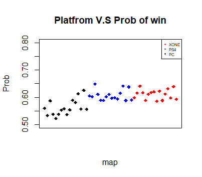

This plot compares performance on different platforms and the x-axis is the map name. The x-axis contains 48 maps(due to the limitation of space, their names are hiden). Generally, Xbox one and Ps4 have similar win rate while PC shows lower win rate.

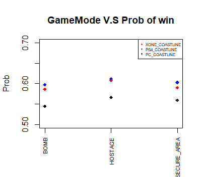

This plot compares probability of win grouped by gamemodes. Each column contains the same gamemode and 3 platform in the same map–Coastline. Generally, mode HOSTAGE has higher win rate.

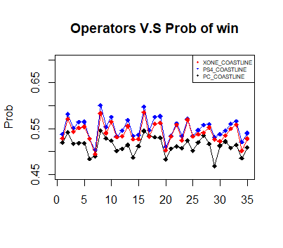

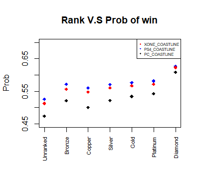

This plot compares probability of win grouped by ranks. Each column contains the same rank and 3 platform in the same map–Coastline. Generally, rank Diamond has much higher win rate.

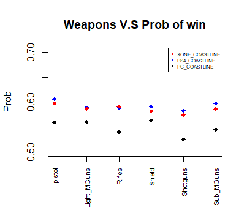

This plot compares probability of win grouped by weapons. Each column contains the same weapon and 3 platform in the same map–Coastline. Generally, weapons show similar performance.

## 3. Conclusion

In the future:

1. We can try SVM or classification tree model and compare them with our glm model.
2. Some variables in our dataset can’t be controlled and they have complex relationship with each others. We could handle this problem in the future.